# EP10 - Regresión Lineal Logística

Equipo 4

2025-06-10

## Pregunta 1

Asegurando reproducibilidad, seleccionar una muestra de 150 mujeres asegurando que la mitad tenga estado nutricional “sobrepeso” y la otra mitad “no sobrepeso” en cada caso. Dividir esta muestra en dos conjuntos: los datos de 100 personas (50 con EN “sobrepeso”) para utilizar en la construcción de los modelos y 50 personas (25 con EN “sobrepeso”) para poder evaluarlos.

```r
# 1. Definir semilla
set.seed(9976)

# 2. Muestra aleatoria 100 mujeres
datos <- read.csv2("EP09 Datos.csv", sep = ";")
variables_og <- colnames(datos)

# Creacion variable IMC
datos$IMC <- datos$Weight / ((datos$Height / 100) **2)

# Crear variable EN (1 si IMC >= 23,2)
datos$EN <- ifelse((datos$IMC >= 23.2), 1, 0)

# Conseguir muestra de 150 mujeres separadas segun EN.
muestra1 <- datos %>%
  mutate(Gender = as.factor(Gender)) %>%
  filter(Gender == 0) %>%
  filter(EN == 1) %>%
  sample_n(75)

muestra2 <- datos %>%
  mutate(Gender = as.factor(Gender)) %>%
  filter(Gender == 0) %>%
  filter(EN == 0) %>%
  sample_n(75)

#MODELO
# Cjto. Entrenamiento -> 70 casos
i_entrenamiento1 <- sample.int(n = nrow(muestra1), size = 50, replace = FALSE)
entrenamiento1 <- muestra1[i_entrenamiento1, ]

# Cjto. Prueba -> 30 casos
prueba1 <- muestra1[-i_entrenamiento1, ]

# Cjto. Entrenamiento -> 70 casos
i_entrenamiento2 <- sample.int(n = nrow(muestra2), size = 50, replace = FALSE)
entrenamiento2 <- muestra2[i_entrenamiento1, ]

# Cjto. Prueba -> 30 casos
prueba2 <- muestra2[-i_entrenamiento2, ]
```

## Pregunta 2

Recordar las ocho posibles variables predictoras seleccionadas de forma aleatoria en el ejercicio anterior.

```r
variables <- c("Wrist.Minimum.Girth", "Waist.Girth", "Knees.diameter", "Forearm.Girth", "Chest.diameter", "Bicep.Girth", "Age", "Chest.Girth")
print(variables)
```

```
## [1] "Wrist.Minimum.Girth" "Waist.Girth"         "Knees.diameter"
## [4] "Forearm.Girth"       "Chest.diameter"      "Bicep.Girth"
## [7] "Age"                 "Chest.Girth"
```

Luego, haremos el complemento de las variables seleccionadas para ver cuáles no fueron sorteadas.

```r
variables <- c(variables, "EN")
otras_variables <- setdiff(colnames(entrenamiento1), variables)
print(otras_variables)
```

```
##  [1] "Biacromial.diameter"     "Biiliac.diameter"
##  [3] "Bitrochanteric.diameter" "Chest.depth"
##  [5] "Elbows.diameter"         "Wrists.diameter"
##  [7] "Ankles.diameter"         "Shoulder.Girth"
##  [9] "Navel.Girth"             "Hip.Girth"
## [11] "Thigh.Girth"             "Knee.Girth"
## [13] "Calf.Maximum.Girth"      "Ankle.Minimum.Girth"
## [15] "Weight"                  "Height"
## [17] "Gender"                  "IMC"
```

## Pregunta 3

Seleccionar, de las otras variables, una que el equipo considere que podría ser útil para predecir la clase EN, justificando bien esta selección (idealmente con literatura).

- “Hip Girth” es mencionado como una de las pocas variables donde las medidas de mujeres tienden a superar las medidas de los hombres.
- “Hip Girth” aparece en un estudio anexado de Behnke & Wilmore (1974, p. 55) donde esta variable es usada como un predictor muy significativo en un modelo de regresión lineal para predecir el peso.

## Pregunta 4

Usando el entorno R, construir un modelo de regresión logística con el predictor seleccionado en el paso anterior y utilizando de la muestra obtenida.

```r
muestra_ent <- rbind(entrenamiento1, entrenamiento2)

# mezclar datos
muestra_ent <- muestra_ent[sample(1:nrow(muestra_ent)), ]

tabla_va <- muestra_ent %>%
  select(all_of(c(variables, "Hip.Girth")))

# cambiar variable despues o justificar xd
modelo_rlog <- glm(EN ~ Hip.Girth, family = binomial(link = "logit"), data = tabla_va)

summary(modelo_rlog)
```

```
##
## Call:
## glm(formula = EN ~ Hip.Girth, family = binomial(link = "logit"),
##     data = tabla_va)
##
## Coefficients:
##             Estimate Std. Error z value Pr(>|z|)
## (Intercept) -47.9877     9.8642  -4.865 1.15e-06 ***
## Hip.Girth     0.4893     0.1006   4.864 1.15e-06 ***
## ---
## Signif. codes:  0 '***' 0.001 '**' 0.01 '*' 0.05 '.' 0.1 ' ' 1
##
## (Dispersion parameter for binomial family taken to be 1)
##
##     Null deviance: 138.629  on 99  degrees of freedom
## Residual deviance:  63.239  on 98  degrees of freedom
## AIC: 67.239
##
## Number of Fisher Scoring iterations: 6
```

## Pregunta 5

Usando estas herramientas para la exploración de modelos del entorno R, buscar entre dos y cinco predictores de entre las variables seleccionadas al azar, recordadas en el punto 2, para agregar al modelo obtenido en el paso 4. Para esto, utilice eliminación hacia atrás, sin usar la función step().

```r
# Empezamos con el modelo completo con las 8 variables
modelo <- glm(EN ~ ., family = binomial(link = "logit"), data = tabla_va)

# Eliminación hacia atrás
paso <- drop1(modelo, test = "F")
print(paso)
```

```
## Single term deletions
##
## Model:
## EN ~ Wrist.Minimum.Girth + Waist.Girth + Knees.diameter + Forearm.Girth +
##     Chest.diameter + Bicep.Girth + Age + Chest.Girth + Hip.Girth
##                     Df Deviance    AIC F value    Pr(>F)
## <none>                   38.251 58.251
## Wrist.Minimum.Girth  1   38.273 56.273  0.0504 0.8229190
## Waist.Girth          1   38.459 56.459  0.4896 0.4859230
## Knees.diameter       1   38.568 56.568  0.7450 0.3903702
## Forearm.Girth        1   38.251 56.251  0.0003 0.9867417
## Chest.diameter       1   38.655 56.655  0.9501 0.3323090
## Bicep.Girth          1   38.289 56.289  0.0887 0.7665279
## Age                  1   41.972 59.972  8.7554 0.0039442 **
## Chest.Girth          1   43.484 61.484 12.3111 0.0007052 ***
## Hip.Girth            1   40.940 58.940  6.3259 0.0136739 *
## ---
## Signif. codes:  0 '***' 0.001 '**' 0.01 '*' 0.05 '.' 0.1 ' ' 1
```

```r
# Quitar Forearm.Girth con F value = 0.0003, el mas bajo
modelo <- update(modelo, . ~ . - Forearm.Girth)

paso <- drop1(modelo, test = "F")
print(paso)
```

```
## Single term deletions
##
## Model:
## EN ~ Wrist.Minimum.Girth + Waist.Girth + Knees.diameter + Chest.diameter +
##     Bicep.Girth + Age + Chest.Girth + Hip.Girth
##                     Df Deviance    AIC F value   Pr(>F)
## <none>                   38.251 56.251
## Wrist.Minimum.Girth  1   38.277 54.277  0.0616 0.804579
## Waist.Girth          1   38.460 54.460  0.4973 0.482509
## Knees.diameter       1   38.605 54.605  0.8413 0.361438
## Chest.diameter       1   38.669 54.669  0.9942 0.321367
## Bicep.Girth          1   38.301 54.301  0.1173 0.732754
## Age                  1   42.043 58.043  9.0208 0.003447 **
## Chest.Girth          1   43.506 59.506 12.5008 0.000642 ***
## Hip.Girth            1   40.992 56.992  6.5190 0.012337 *
## ---
## Signif. codes:  0 '***' 0.001 '**' 0.01 '*' 0.05 '.' 0.1 ' ' 1
```

```r
# Quitar Wrist.Minimum.Girth con F value = 0.0616, el mas bajo
modelo <- update(modelo, . ~ . - Wrist.Minimum.Girth)
paso <- drop1(modelo, test = "F")
print(paso)
```

```
## Single term deletions
##
## Model:
## EN ~ Waist.Girth + Knees.diameter + Chest.diameter + Bicep.Girth +
##     Age + Chest.Girth + Hip.Girth
##                Df Deviance    AIC F value    Pr(>F)
## <none>              38.277 54.277
## Waist.Girth     1   38.492 52.492  0.5166 0.4741009
## Knees.diameter  1   38.606 52.606  0.7904 0.3763058
## Chest.diameter  1   39.010 53.010  1.7624 0.1876152
## Bicep.Girth     1   38.353 52.353  0.1813 0.6712918
## Age             1   43.015 57.015 11.3870 0.0010842 **
## Chest.Girth     1   44.006 58.006 13.7699 0.0003535 ***
## Hip.Girth       1   40.993 54.993  6.5277 0.0122624 *
## ---
## Signif. codes:  0 '***' 0.001 '**' 0.01 '*' 0.05 '.' 0.1 ' ' 1
```

```r
# Quitar Bicep.Girth con F value = 0.1813, el mas bajo
modelo <- update(modelo, . ~ . - Bicep.Girth)
paso <- drop1(modelo, test = "F")
print(paso)
```

```
## Single term deletions
##
## Model:
## EN ~ Waist.Girth + Knees.diameter + Chest.diameter + Age + Chest.Girth +
##     Hip.Girth
##                Df Deviance    AIC F value   Pr(>F)
## <none>              38.353 52.353
## Waist.Girth     1   38.648 50.648  0.7165 0.399483
## Knees.diameter  1   38.615 50.615  0.6350 0.427546
## Chest.diameter  1   39.014 51.014  1.6044 0.208439
## Age             1   43.054 55.054 11.3994 0.001074 **
## Chest.Girth     1   46.082 58.082 18.7419 3.77e-05 ***
## Hip.Girth       1   41.189 53.189  6.8769 0.010203 *
## ---
## Signif. codes:  0 '***' 0.001 '**' 0.01 '*' 0.05 '.' 0.1 ' ' 1
```

```r
# Quitar Knee.diameter con F value = 0.6350
modelo <- update(modelo, . ~ . - Knees.diameter)
paso <- drop1(modelo, test = "F")
print(paso)
```

```
## Single term deletions
##
## Model:
## EN ~ Waist.Girth + Chest.diameter + Age + Chest.Girth + Hip.Girth
##                Df Deviance    AIC F value   Pr(>F)
## <none>              38.615 50.615
## Waist.Girth     1   38.872 48.872  0.6275 0.430284
## Chest.diameter  1   39.072 49.072  1.1127 0.294205
## Age             1   43.112 53.112 10.9491 0.001328 **
## Chest.Girth     1   46.250 56.250 18.5865    4e-05 ***
## Hip.Girth       1   42.942 52.942 10.5354 0.001623 **
## ---
## Signif. codes:  0 '***' 0.001 '**' 0.01 '*' 0.05 '.' 0.1 ' ' 1
```

```r
# Quitar Waist.Girth con F value = 0.6275, el mas bajo
modelo <- update(modelo, . ~ . - Waist.Girth)
paso <- drop1(modelo, test = "F")
print(paso)
```

```
## Single term deletions
##
## Model:
## EN ~ Chest.diameter + Age + Chest.Girth + Hip.Girth
##                Df Deviance    AIC F value    Pr(>F)
## <none>              38.872 48.872
## Chest.diameter  1   39.774 47.774  2.2034   0.14102
## Age             1   43.422 51.422 11.1193   0.00122 **
## Chest.Girth     1   53.154 61.154 34.9024 5.382e-08 ***
## Hip.Girth       1   47.968 55.968 22.2295 8.283e-06 ***
## ---
## Signif. codes:  0 '***' 0.001 '**' 0.01 '*' 0.05 '.' 0.1 ' ' 1
```

```r
# Quitar Chest.diameter con F value = 2.2034, el mas bajo
modelo <- update(modelo, . ~ .  - Chest.diameter)
paso <- drop1(modelo, test = "F")
print(paso)
```

```
## Single term deletions
##
## Model:
## EN ~ Age + Chest.Girth + Hip.Girth
##             Df Deviance    AIC F value    Pr(>F)
## <none>           39.774 47.774
## Age          1   44.922 50.922  12.425 0.0006509 ***
## Chest.Girth  1   54.891 60.891  36.488 2.906e-08 ***
## Hip.Girth    1   48.846 54.846  21.897 9.429e-06 ***
## ---
## Signif. codes:  0 '***' 0.001 '**' 0.01 '*' 0.05 '.' 0.1 ' ' 1
```

```r
summary(modelo)
```

```
##
## Call:
## glm(formula = EN ~ Age + Chest.Girth + Hip.Girth, family = binomial(link = "logit"),
##     data = tabla_va)
##
## Coefficients:
##              Estimate Std. Error z value Pr(>|z|)
## (Intercept) -80.22799   19.49904  -4.114 3.88e-05 ***
## Age           0.10796    0.05205   2.074  0.03806 *
## Chest.Girth   0.57190    0.19230   2.974  0.00294 **
## Hip.Girth     0.27670    0.10967   2.523  0.01163 *
## ---
## Signif. codes:  0 '***' 0.001 '**' 0.01 '*' 0.05 '.' 0.1 ' ' 1
##
## (Dispersion parameter for binomial family taken to be 1)
##
##     Null deviance: 138.629  on 99  degrees of freedom
## Residual deviance:  39.774  on 96  degrees of freedom
## AIC: 47.774
##
## Number of Fisher Scoring iterations: 7
```

Habiendo realizado la eliminación de variables hacia atrás, dejando sólo aquellas que aportan significativamente al modelo, se ha llegado a un modelo más parsimonioso, el cual tiene las siguientes variables predictoras:

- Hip.Girth (Circunferencia de la cadera)
- Age (Edad)
- Chest.Girth (Circunferencia del pecho)

## Pregunta 6

A continuación estudiaremos la confiabilidad del modelo seleccionado. Para esto se deben cumplir las siguientes condiciones:

**1. Debe existir una relación lineal entre los predictores y la respuesta transformada**

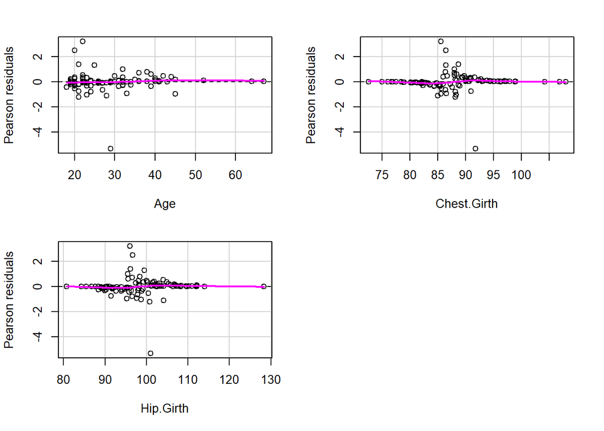

```
##             Test stat Pr(>|Test stat|)
## Age            0.2184           0.6402
## Chest.Girth    1.1033           0.2935
## Hip.Girth      0.5627           0.4532
```

```r
#Evaluar usando la funcion residualPlots() del paquete car}
residualPlots(modelo, fitted = FALSE)
```

**2. Los residuos deben ser independientes entre sí.**

```r
#usando la funcion durbinWatsonTest() del paquete car
dbw <- durbinWatsonTest(modelo)
dbw
```

```
##  lag Autocorrelation D-W Statistic p-value
##    1      -0.1274116      2.254815    0.19
##  Alternative hypothesis: rho != 0
```

Se puede concluir que los residuos son independientes entre sí, ya que el valor del estadístico Durbin-Watson es cercano a 2 y el valor p = 0.19 no es significativo, lo que indica que no hay autocorrelación.

Con esto verificamos que efectivamente se está cumpliendo la independencia de los residuos.

**3. Multicolinealidad entre los predictores.**

```r
#usando la funcion vif() del paquete car
vif_values <- vif(modelo)
vif_values
```

```
##         Age Chest.Girth   Hip.Girth
##    1.048821    1.055909    1.009689
```

Los valores de VIF, no sobrepasan el umbral de 5 (considerado como un umbral preocupante), por lo que no hay evidencia de multicolinealidad entre los predictores.

**4. Observaciones suficientes para estimar los parámetros del modelo, sin información incompleta.**

Para evaluar esto, se puede observar el número de observaciones por cada predictor en el modelo. Se recomienda que hayan más de 10 o 15 observaciones por cada predictor y nivel de las variables categóricas.

En nuestro caso, recordando las instrucciones del enunciado, ya tenemos 50 observaciones para cada clase de EN (0 y 1). Para comprobar con los predictores:

```r
mostrar_obs <- function(predictor) {
  n_predictor <- length(unique(tabla_va[[predictor]]))
  sprintf("Observaciones: %d", n_predictor)
}

sapply(c("Hip.Girth", "Age", "Chest.Girth"), mostrar_obs)
```

```
##           Hip.Girth                 Age         Chest.Girth
## "Observaciones: 85" "Observaciones: 30" "Observaciones: 77"
```

Vemos que para cada predictor hay observaciones suficientes. Además, con un total de 100 observaciones, no hay evidencia de información incompleta.

**5. Separacion perfecta que ocurre cuando no hay superposicion entre las clases.**

En este caso los predictores no presentan separación perfecta, ya que hay observaciones de ambas clases en cada uno de los predictores. Por lo tanto, no hay evidencia de separacion perfecta. ya que por ejemplo, en el predictor Hip.Girth, hay observaciones de ambas clases (EN = 0 y EN = 1) para todos los valores de Hip.Girth.

**6. Las estimaciones de los coeficicientes no estan dominadas por casos influyentes.**

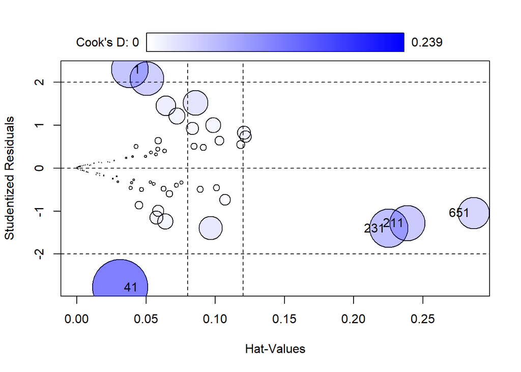

```r
# Usando la funcion influencePlot() del paquete car
inf <- influencePlot(modelo)
```

```r
print(inf)
```

```
##       StudRes        Hat      CookD
## 41  -2.773790 0.03143729 0.23877424
## 211 -1.280963 0.23885831 0.09846591
## 231 -1.402556 0.22524208 0.11582866
## 651 -1.046695 0.28661070 0.07727720
## 1    2.294681 0.03823475 0.10674752
```

Esto es suficiente para concluir que no hay evidencia de que las estimaciones de los coeficientes esten dominadas por casos influyentes. Por lo tanto podemos decir que se cumple la sexta condición.

Finalmente, luego de comprobar las condiciones de confiabilidad del modelo, podemos concluir que el modelo cumple con todas las condiciones necesarias para ser considerado confiable.

## Pregunta 7

A partir del modelo definido en la pregunta 5, se determinará el poder predictivo de este, utilizando un conjunto de 50 mujeres (25 con EN = 1 y 25 con EN = 0) que no fueron incluidas a la hora de la construcción del modelo. En particular se calculará la sensibilidad y especificidad del modelo, permitiéndonos juzgar la capacidad de generalización de este.

- La **sensibilidad** nos indica la capacidad del modelo para identificar correctamente los casos positivos.
- La **especificidad** nos indica la capacidad del modelo para identificar correctamente los casos negativos.

```r
# Combinar los dos dataframes de prueba en uno solo.
# 25 con EN=1 y 25 con EN=0
muestra_pru <- rbind(prueba1, prueba2)

# Obtener las probabilidades predichas para el conjunto de prueba.
probabilidades_pru <- predict(modelo, newdata = muestra_pru, type = "response")

# Umbral de clasificación en 0.5.
umbral <- 0.5

predicciones_clase <- ifelse(probabilidades_pru >= umbral, 1, 0)

observados_clase <- muestra_pru$EN

# Se calculan los componentes de la matriz de confusión.
# Verdaderos Positivos (VP)
VP <- sum(predicciones_clase == 1 & observados_clase == 1)

# Verdaderos Negativos (VN)
VN <- sum(predicciones_clase == 0 & observados_clase == 0)

# Falsos Positivos (FP)
FP <- sum(predicciones_clase == 1 & observados_clase == 0)

# Falsos Negativos (FN)
FN <- sum(predicciones_clase == 0 & observados_clase == 1)

# Calcular la sensibilidad
sensibilidad <- VP / (VP + FN)

# Calcular la especificidad
especificidad <- VN / (FP + VN)
```

```r
# Imprimir la matriz de confusión para visualizar el rendimiento.
cat("Matriz de Confusión (Datos de Prueba):\n")
```

```
## Matriz de Confusión (Datos de Prueba):
```

```r
# crear tabla a mano con los valores de VP, FP, VN, FN
matriz <- data.frame(
  Predicho = c("Positivo", "Negativo"),
  Real_Positivo = c(VP, FN),
  Real_Negativo = c(FP, VN)
)
print(matriz)
```

```
##   Predicho Real_Positivo Real_Negativo
## 1 Positivo            20             2
## 2 Negativo             5            23
```

```r
# Imprimir las métricas calculadas.
sprintf("Sensibilidad del modelo: %.4f\n", sensibilidad)
```

```
## [1] "Sensibilidad del modelo: 0.8000\n"
```

```r
sprintf("Especificidad del modelo: %.4f\n", especificidad)
```

```
## [1] "Especificidad del modelo: 0.9200\n"
```

Podemos observar que el modelo construido demuestra un buen poder predictivo sobre el conjunto de prueba, aunque un poco desbalanceado ya que es más específico que sensible. Es decir, es más probable que el modelo identifique correctamente mujeres que no tienen sobrepeso que este logre identificar a las mujeres que sí tienen. En general, el modelo demuestra una buena capacidad de generalización para ser aplicado con datos nuevos.